# DRM Model Selection: SNR and Distributional Robustness

Nested linear-regression simulation

# Nested Linear model

$$M_1:Y\sim X_1,
\qquad
M_2:Y\sim X_1+X_2+X_3.$$

$$Y=1+\beta_1X_1+\delta X_2+\delta X_3(+\varepsilon).$$

The simulation is divided into two cases because they answer different model-selection questions.

### Case 1: the simpler model M1 is true

$$\delta=0.$$

Both models contain the true conditional mean, but the larger model contains two useless predictors. This case measures whether a selection method can prefer the simpler model when predictive distributions are very similar.

### Case 2: the larger model M2 is true

$$\delta>0.$$

The simpler model omits relevant predictors. This case measures whether a selection method detects the additional signal contained in the larger model.

### Sensitivity Check

#### Signal-to-Noise Ratio

The total signal-to-noise ratio is

$$\mathrm{SNR}_{\mathrm{total}}
=
\frac{\operatorname{Var}(\beta_1X_1+\delta X_2+\delta X_3)}
{\operatorname{Var}(\varepsilon)}.$$

For nested model selection, the more relevant quantity in Case 2 is the discriminating SNR:

$$\mathrm{SNR}_{\mathrm{disc}}
=
\frac{\operatorname{Var}(\delta X_2+\delta X_3)}
{\operatorname{Var}(\varepsilon)}=2\delta^2.$$

Changing a **coefficient** (effect size), **predictor variance**, or **error variance** can therefore be described through SNR.

#### Distribution shape

Changing the distribution shape of a **predictor** or **error** term while holding its mean and variance fixed, to test the robustness of our strategy.

We generate data from 4 distribution shape with fixed mean 0 and variance 1.

| distribution | mean | variance | skewness |
| --- | --- | --- | --- |
| normal | 0.0019 | 1.0013 | 0.0005 |
| heavy_tail_t5 | 0.0020 | 0.9961 | -0.0108 |
| right_skewed | -0.0031 | 0.9827 | 1.9484 |
| contaminated_normal | 0.0050 | 1.0159 | 0.0320 |

### Research Design

We use five DRM metrics with basis function:

$$q(y)=(y,y^2).$$

We also introduce AIC as a benchmark.

For each scenario, one **test set** (without noise) is generated before the **500** times Monte Carlo loop and remains **fixed**, Only the training set changes across iterations.

## Representative nested scenarios

$$X_1,X_2,X_3\overset{\mathrm{iid}}{\sim}N(0,1),$$

For each scenario, the fixed test response is noiseless. Two training responses are constructed from the same training predictors:

$$Y_{\mathrm{test}}=1+\beta_1X_1+\delta X_2+\delta X_3,$$

$$Y_{\mathrm{train,without}}=1+\beta_1X_1+\delta X_2+\delta X_3,$$

$$Y_{\mathrm{train,with}}=1+\beta_1X_1+\delta X_2+\delta X_3+\varepsilon,
\qquad \varepsilon\sim N(0,1).$$

### 1. simpler model is true

$$Y_{\mathrm{test}}=Y_{\mathrm{train,without}}=1+X_1,$$

$$Y_{\mathrm{train,with}}=1+X_1+\varepsilon.$$

Representative 1: correct-selection accuracy

| Prediction output | log_ratio | Jeffreys | CDF | Joint_Wald | Joint_DELR | AIC |
| --- | --- | --- | --- | --- | --- | --- |
| Without noise | 1.000 | 1.000 | 1.000 | 1.000 | 1.000 | 0.882 |
| With noise | 0.488 | 0.506 | 0.496 | 0.506 | 0.506 | 0.858 |

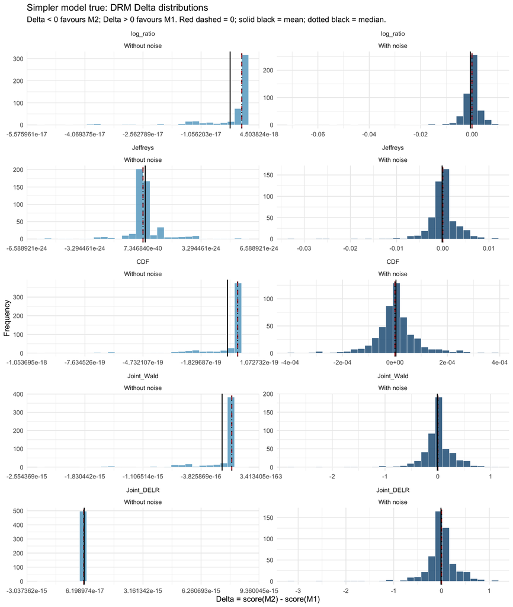

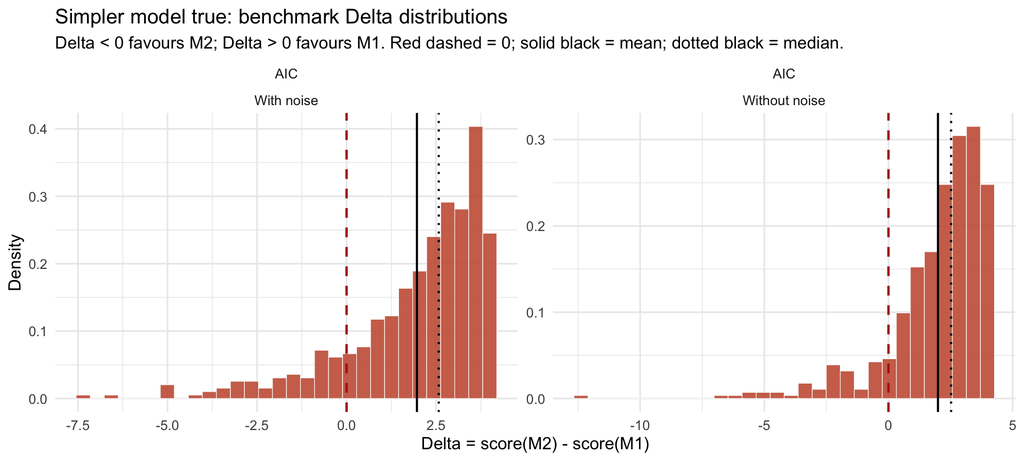

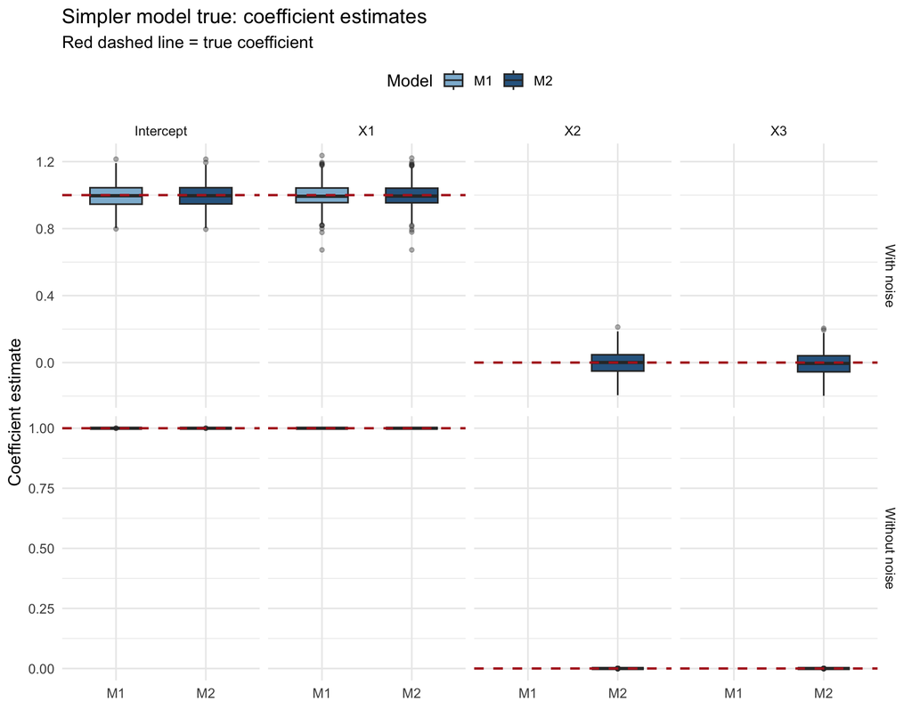

### 2. larger model is true

$$Y_{\mathrm{test}}=Y_{\mathrm{train,without}}=1+X_1+X_2+X_3,$$

$$Y_{\mathrm{train,with}}=1+X_1+X_2+X_3+\varepsilon.$$

Representative 2: correct-selection accuracy

| Prediction output | log_ratio | Jeffreys | CDF | Joint_Wald | Joint_DELR | AIC |
| --- | --- | --- | --- | --- | --- | --- |
| Without noise | 1.000 | 1.000 | 1.000 | 1.000 | 1.000 | 1.000 |
| With noise | 1.000 | 1.000 | 1.000 | 1.000 | 1.000 | 1.000 |

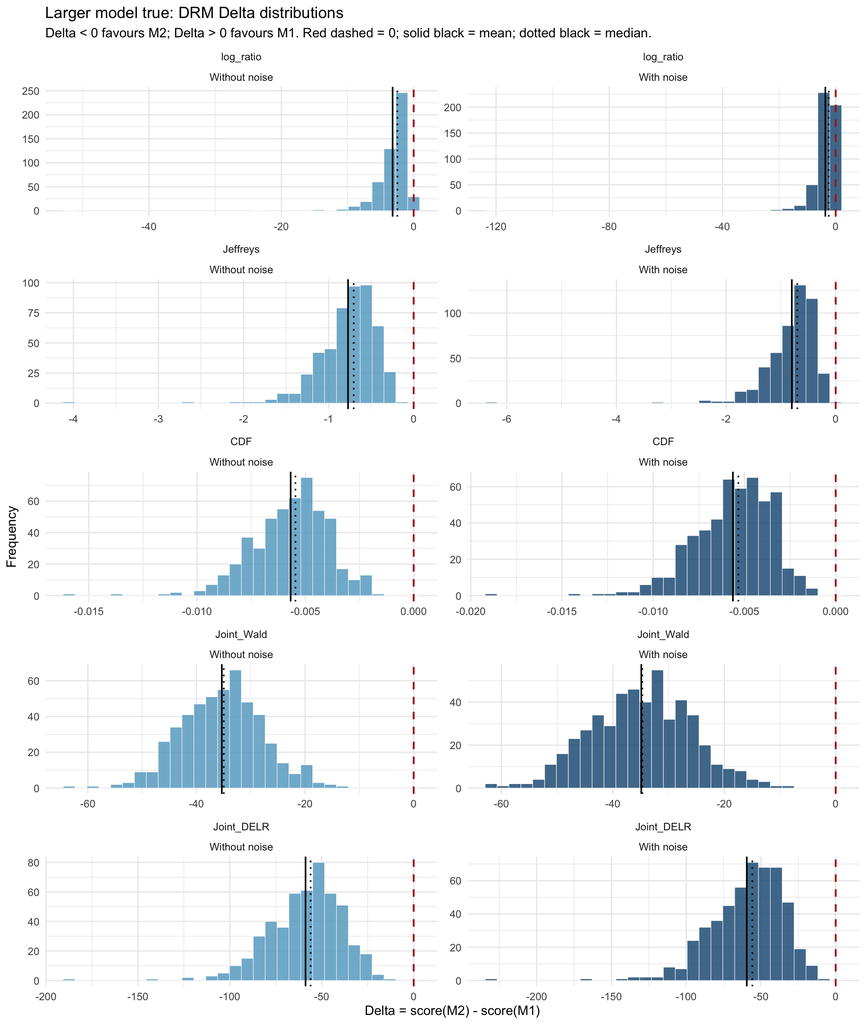

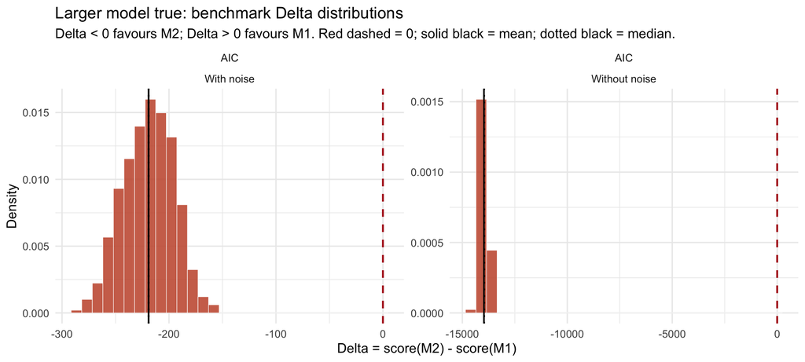

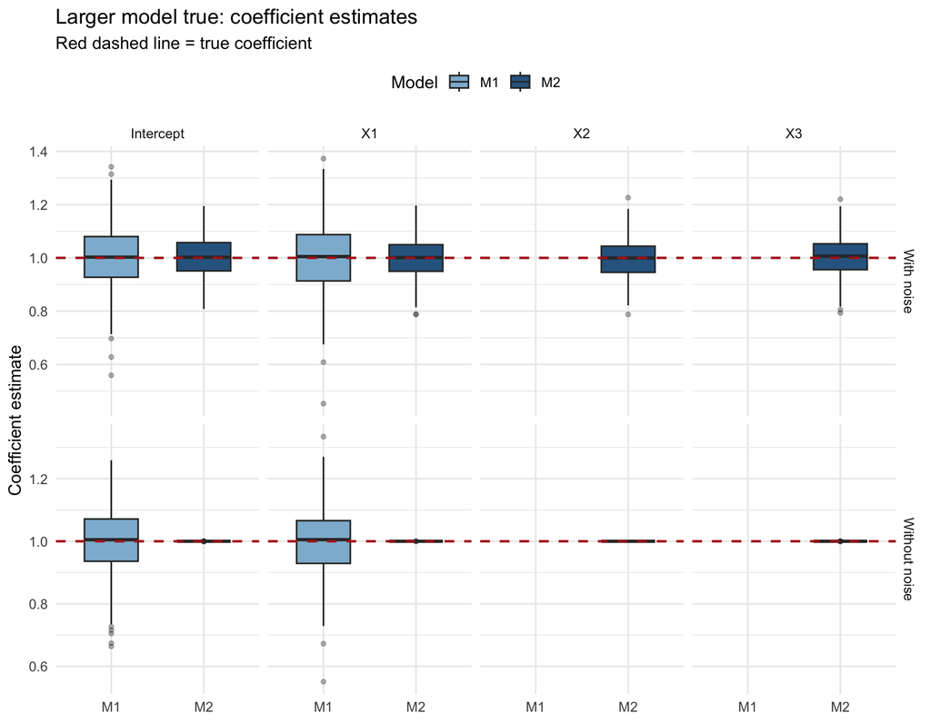

## Part I: SNR experiments

### Experiment 1A: the simpler model is true

$$Y=1+\beta_1X_1+\varepsilon,$$

Both candidate models contain the true signal. The shared SNR is

$$\mathrm{SNR}_{\mathrm{shared}}=\frac{\beta_1^2 \sigma_{x_1}^2}{\sigma_\epsilon ^2}.$$

This finite SNR applies only to the **with-noise training** condition. Without-noise training has zero error variance and therefore infinite SNR; it is reported separately in the representative baseline rather than along the SNR curve.

The shared SNR was also varied by changing the **predictor standard deviation** or the **observation-error standard deviation**. These three parameterisations produced essentially the *same* *selection pattern* at matched SNR values, so the **coefficient**-based implementation is used in the main results for clarity.

Three equivalent parameterisations of shared SNR

| shared_snr | implementation | beta_1 | x1_sd | sigma_error |
| --- | --- | --- | --- | --- |
| 0.25 | Coefficient | 0.5 | 1.0 | 1.000 |
| 0.25 | Predictor SD | 1.0 | 0.5 | 1.000 |
| 0.25 | Error SD | 1.0 | 1.0 | 2.000 |
| 1.00 | Coefficient | 1.0 | 1.0 | 1.000 |
| 1.00 | Predictor SD | 1.0 | 1.0 | 1.000 |
| 1.00 | Error SD | 1.0 | 1.0 | 1.000 |
| 9.00 | Coefficient | 3.0 | 1.0 | 1.000 |
| 9.00 | Predictor SD | 1.0 | 3.0 | 1.000 |
| 9.00 | Error SD | 1.0 | 1.0 | 0.333 |
| 16.00 | Coefficient | 4.0 | 1.0 | 1.000 |
| 16.00 | Predictor SD | 1.0 | 4.0 | 1.000 |
| 16.00 | Error SD | 1.0 | 1.0 | 0.250 |
| 25.00 | Coefficient | 5.0 | 1.0 | 1.000 |
| 25.00 | Predictor SD | 1.0 | 5.0 | 1.000 |
| 25.00 | Error SD | 1.0 | 1.0 | 0.200 |

**Conclu:** Increasing this quantity strengthens signal shared by both candidates; it does not increase their structural difference. DRM methods have no explicit **complexity penalty**, so their accuracy may remain close to **chance level** even when shared SNR is high.

**Simpler model true: accuracy by shared SNR**

With noise training: accuracy [95% Monte Carlo CI]

| shared_snr | log_ratio | Jeffreys | CDF | Joint_Wald | Joint_DELR | AIC |
| --- | --- | --- | --- | --- | --- | --- |
| 0.25 | 0.446 [0.402, 0.490] | 0.480 [0.436, 0.524] | 0.498 [0.454, 0.542] | 0.482 [0.438, 0.526] | 0.478 [0.434, 0.522] | 0.858 [0.827, 0.889] |
| 1.00 | 0.488 [0.444, 0.532] | 0.506 [0.462, 0.550] | 0.496 [0.452, 0.540] | 0.506 [0.462, 0.550] | 0.506 [0.462, 0.550] | 0.858 [0.827, 0.889] |
| 9.00 | 0.518 [0.474, 0.562] | 0.518 [0.474, 0.562] | 0.492 [0.448, 0.536] | 0.518 [0.474, 0.562] | 0.518 [0.474, 0.562] | 0.858 [0.827, 0.889] |
| 16.00 | 0.520 [0.476, 0.564] | 0.522 [0.478, 0.566] | 0.498 [0.454, 0.542] | 0.522 [0.478, 0.566] | 0.522 [0.478, 0.566] | 0.858 [0.827, 0.889] |
| 25.00 | 0.526 [0.482, 0.570] | 0.526 [0.482, 0.570] | 0.502 [0.458, 0.546] | 0.526 [0.482, 0.570] | 0.526 [0.482, 0.570] | 0.858 [0.827, 0.889] |

**Simpler model true: Delta by shared SNR**

With noise training: mean Delta [2.5%, 97.5% empirical quantiles]

| shared_snr | log_ratio | Jeffreys | CDF | Joint_Wald | Joint_DELR | AIC |
| --- | --- | --- | --- | --- | --- | --- |
| 0.25 | -0.042 [-0.123, 0.018] | -0.005 [-0.045, 0.028] | -0.000 [-0.001, 0.001] | -0.166 [-3.633, 2.387] | -0.305 [-4.118, 2.686] | 1.965 [-3.133, 3.968] |
| 1.00 | -0.001 [-0.009, 0.006] | -0.000 [-0.007, 0.006] | 0.000 [-0.000, 0.000] | -0.009 [-0.651, 0.585] | -0.012 [-0.680, 0.598] | 1.965 [-3.133, 3.968] |
| 9.00 | 0.000 [-0.001, 0.001] | 0.000 [-0.001, 0.001] | 0.000 [-0.000, 0.000] | 0.001 [-0.067, 0.068] | 0.001 [-0.067, 0.069] | 1.965 [-3.133, 3.968] |
| 16.00 | 0.000 [-0.000, 0.000] | 0.000 [-0.000, 0.000] | 0.000 [-0.000, 0.000] | 0.001 [-0.036, 0.039] | 0.001 [-0.036, 0.039] | 1.965 [-3.133, 3.968] |
| 25.00 | 0.000 [-0.000, 0.000] | 0.000 [-0.000, 0.000] | 0.000 [-0.000, 0.000] | 0.000 [-0.023, 0.025] | 0.000 [-0.023, 0.025] | 1.965 [-3.133, 3.968] |

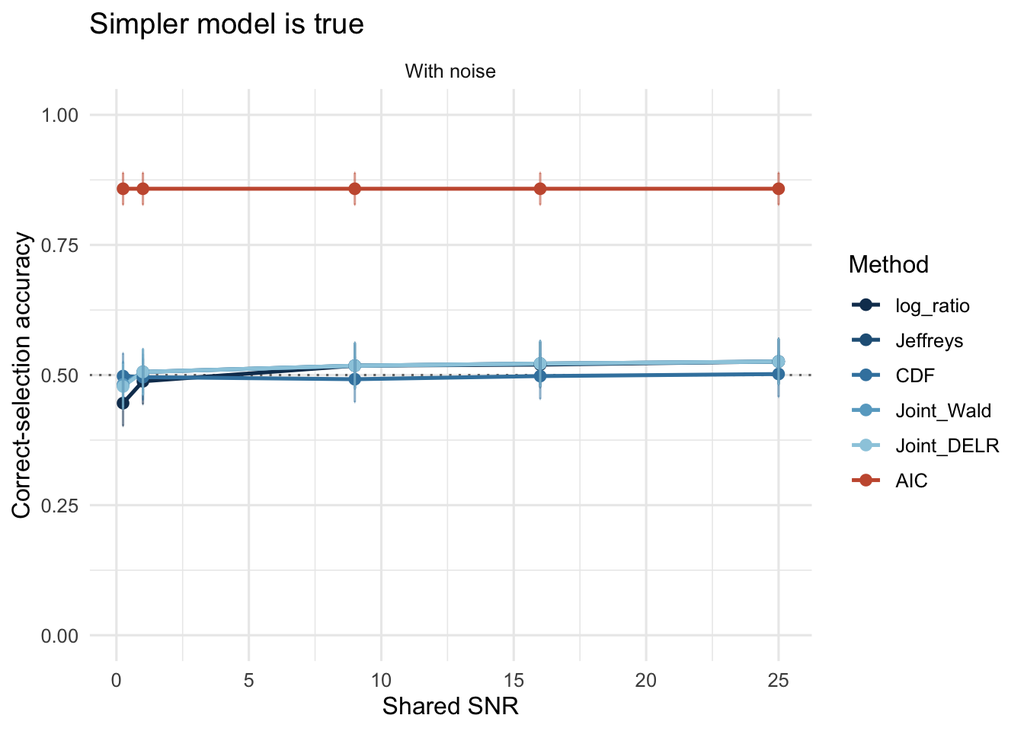

### Experiment 1B: the larger model is true

Here the larger model contains additional true signal. With unit predictor and error variances,

$$\delta=\sqrt{\mathrm{SNR}_{\mathrm{disc}}/2}.$$

The zero point is excluded because it belongs to Experiment 1A, where the simpler model is true.

The same SNR equivalence applies here: changing the coefficient, predictor variance, or error variance produced essentially the same selection pattern at matched discriminating SNR values.

**Conclu:** When the larger model is true, models fitted to noisy training data require sufficient discriminating signal to identify the additional predictors. At low SNR, the observation error in the training response can obscure the additional signal; selection improves as the discriminating SNR increases.

The SNR curve reports only the with-noise training condition. The corresponding noiseless case is shown separately in the representative baseline.

**Larger model true: accuracy by discriminating SNR**

With noise training: accuracy [95% Monte Carlo CI]

| discriminating_snr | log_ratio | Jeffreys | CDF | Joint_Wald | Joint_DELR | AIC |
| --- | --- | --- | --- | --- | --- | --- |
| 0.25 | 0.826 [0.793, 0.859] | 0.802 [0.767, 0.837] | 0.802 [0.767, 0.837] | 0.802 [0.767, 0.837] | 0.802 [0.767, 0.837] | 1.000 [1.000, 1.000] |
| 1.00 | 0.998 [0.994, 1.000] | 0.998 [0.994, 1.000] | 0.998 [0.994, 1.000] | 0.998 [0.994, 1.000] | 0.998 [0.994, 1.000] | 1.000 [1.000, 1.000] |
| 9.00 | 1.000 [1.000, 1.000] | 1.000 [1.000, 1.000] | 1.000 [1.000, 1.000] | 1.000 [1.000, 1.000] | 1.000 [1.000, 1.000] | 1.000 [1.000, 1.000] |
| 16.00 | 1.000 [1.000, 1.000] | 1.000 [1.000, 1.000] | 1.000 [1.000, 1.000] | 1.000 [1.000, 1.000] | 1.000 [1.000, 1.000] | 1.000 [1.000, 1.000] |
| 25.00 | 1.000 [1.000, 1.000] | 1.000 [1.000, 1.000] | 1.000 [1.000, 1.000] | 1.000 [1.000, 1.000] | 1.000 [1.000, 1.000] | 1.000 [1.000, 1.000] |

**Larger model true: Delta by discriminating SNR**

With noise training: mean Delta [2.5%, 97.5% empirical quantiles]

| discriminating_snr | log_ratio | Jeffreys | CDF | Joint_Wald | Joint_DELR | AIC |
| --- | --- | --- | --- | --- | --- | --- |
| 0.25 | -0.058 [-0.262, 0.020] | -0.035 [-0.141, 0.026] | -0.000 [-0.002, 0.000] | -3.019 [-11.156, 2.437] | -3.366 [-13.260, 2.530] | -43.188 [-70.676, -20.056] |
| 1.00 | -0.764 [-2.521, -0.082] | -0.294 [-0.712, -0.056] | -0.003 [-0.006, -0.001] | -18.360 [-32.985, -4.941] | -25.315 [-55.269, -5.386] | -137.708 [-178.549, -101.855] |
| 9.00 | -18814.025 [-622.586, -7.869] | -8.563 [-14.110, -1.383] | -0.015 [-0.023, -0.009] | -56.847 [-61.309, -48.454] | -188.925 [-303.141, -95.270] | -460.202 [-509.578, -405.811] |
| 16.00 | -11093.456 [-5491.951, -18.191] | -14.385 [-41.680, -2.217] | -0.019 [-0.028, -0.011] | -58.473 [-63.606, -51.805] | -249.155 [-403.451, -129.851] | -566.378 [-617.171, -511.337] |
| 25.00 | -82439.575 [-41479.912, -32.918] | -33.175 [-113.835, -3.049] | -0.022 [-0.031, -0.013] | -57.642 [-62.429, -46.419] | -295.875 [-485.124, -156.024] | -651.378 [-702.540, -594.919] |

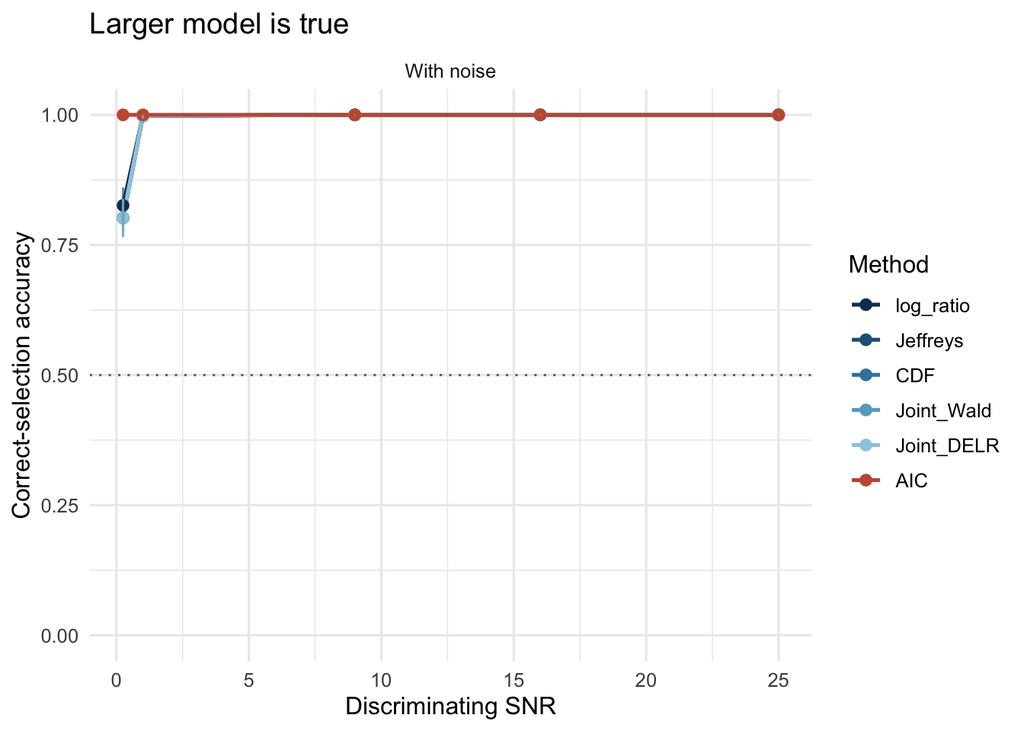

## Part II: distributional robustness

The robustness experiments are also separated by the true model. In both cases, all compared distributions have mean zero and variance one.

**Concl:** Overall, changing the **predictor or error distribution shape does not fundamentally alter the selection pattern.**

### Experiment 2: changing the predictor distribution

For the simpler-true case, changing the distribution of the useless predictors examines finite-sample overfitting. For the larger-true case, the discriminating SNR is fixed at

$$\mathrm{SNR}_{\mathrm{disc}}=2.$$

**Accuracy under different predictor distributions**

Without noise training: accuracy [95% Monte Carlo CI]

| true_model | predictor_distribution | log_ratio | Jeffreys | CDF | Joint_Wald | Joint_DELR | AIC |
| --- | --- | --- | --- | --- | --- | --- | --- |
| Simpler model true | normal | 1.000 [1.000, 1.000] | 1.000 [1.000, 1.000] | 1.000 [1.000, 1.000] | 1.000 [1.000, 1.000] | 1.000 [1.000, 1.000] | 0.872 [0.843, 0.901] |
| Larger model true | normal | 1.000 [1.000, 1.000] | 1.000 [1.000, 1.000] | 1.000 [1.000, 1.000] | 1.000 [1.000, 1.000] | 1.000 [1.000, 1.000] | 1.000 [1.000, 1.000] |
| Simpler model true | heavy_tail_t5 | 1.000 [1.000, 1.000] | 1.000 [1.000, 1.000] | 1.000 [1.000, 1.000] | 1.000 [1.000, 1.000] | 1.000 [1.000, 1.000] | 0.856 [0.825, 0.887] |
| Larger model true | heavy_tail_t5 | 1.000 [1.000, 1.000] | 1.000 [1.000, 1.000] | 1.000 [1.000, 1.000] | 1.000 [1.000, 1.000] | 1.000 [1.000, 1.000] | 1.000 [1.000, 1.000] |
| Simpler model true | right_skewed | 1.000 [1.000, 1.000] | 1.000 [1.000, 1.000] | 1.000 [1.000, 1.000] | 1.000 [1.000, 1.000] | 1.000 [1.000, 1.000] | 0.876 [0.847, 0.905] |
| Larger model true | right_skewed | 1.000 [1.000, 1.000] | 1.000 [1.000, 1.000] | 1.000 [1.000, 1.000] | 1.000 [1.000, 1.000] | 1.000 [1.000, 1.000] | 1.000 [1.000, 1.000] |
| Simpler model true | contaminated_normal | 1.000 [1.000, 1.000] | 1.000 [1.000, 1.000] | 1.000 [1.000, 1.000] | 1.000 [1.000, 1.000] | 1.000 [1.000, 1.000] | 0.916 [0.892, 0.940] |
| Larger model true | contaminated_normal | 1.000 [1.000, 1.000] | 1.000 [1.000, 1.000] | 1.000 [1.000, 1.000] | 1.000 [1.000, 1.000] | 1.000 [1.000, 1.000] | 1.000 [1.000, 1.000] |

With noise training: accuracy [95% Monte Carlo CI]

| true_model | predictor_distribution | log_ratio | Jeffreys | CDF | Joint_Wald | Joint_DELR | AIC |
| --- | --- | --- | --- | --- | --- | --- | --- |
| Simpler model true | normal | 0.526 [0.482, 0.570] | 0.530 [0.486, 0.574] | 0.532 [0.488, 0.576] | 0.532 [0.488, 0.576] | 0.530 [0.486, 0.574] | 0.858 [0.827, 0.889] |
| Larger model true | normal | 1.000 [1.000, 1.000] | 1.000 [1.000, 1.000] | 1.000 [1.000, 1.000] | 1.000 [1.000, 1.000] | 1.000 [1.000, 1.000] | 1.000 [1.000, 1.000] |
| Simpler model true | heavy_tail_t5 | 0.482 [0.438, 0.526] | 0.482 [0.438, 0.526] | 0.480 [0.436, 0.524] | 0.488 [0.444, 0.532] | 0.484 [0.440, 0.528] | 0.858 [0.827, 0.889] |
| Larger model true | heavy_tail_t5 | 1.000 [1.000, 1.000] | 1.000 [1.000, 1.000] | 0.998 [0.994, 1.000] | 1.000 [1.000, 1.000] | 1.000 [1.000, 1.000] | 1.000 [1.000, 1.000] |
| Simpler model true | right_skewed | 0.502 [0.458, 0.546] | 0.506 [0.462, 0.550] | 0.524 [0.480, 0.568] | 0.502 [0.458, 0.546] | 0.506 [0.462, 0.550] | 0.860 [0.830, 0.890] |
| Larger model true | right_skewed | 1.000 [1.000, 1.000] | 1.000 [1.000, 1.000] | 1.000 [1.000, 1.000] | 1.000 [1.000, 1.000] | 1.000 [1.000, 1.000] | 1.000 [1.000, 1.000] |
| Simpler model true | contaminated_normal | 0.540 [0.496, 0.584] | 0.552 [0.508, 0.596] | 0.546 [0.502, 0.590] | 0.554 [0.510, 0.598] | 0.552 [0.508, 0.596] | 0.886 [0.858, 0.914] |
| Larger model true | contaminated_normal | 1.000 [1.000, 1.000] | 1.000 [1.000, 1.000] | 1.000 [1.000, 1.000] | 1.000 [1.000, 1.000] | 1.000 [1.000, 1.000] | 1.000 [1.000, 1.000] |

**Delta under different predictor distributions**

Without noise training: mean Delta [2.5%, 97.5% empirical quantiles]

| true_model | predictor_distribution | log_ratio | Jeffreys | CDF | Joint_Wald | Joint_DELR | AIC |
| --- | --- | --- | --- | --- | --- | --- | --- |
| Simpler model true | normal | -0.000 [-0.000, 0.000] | 0.000 [-0.000, 0.000] | -0.000 [-0.000, 0.000] | -0.000 [-0.000, 0.000] | -0.000 [0.000, 0.000] | 1.937 [-3.601, 3.966] |
| Larger model true | normal | -5.892 [-16.527, -1.482] | -1.211 [-2.303, -0.546] | -0.009 [-0.014, -0.005] | -42.989 [-55.073, -31.274] | -83.643 [-132.196, -46.109] | -13969.174 [-14294.177, -13731.942] |
| Simpler model true | heavy_tail_t5 | -0.000 [-0.000, 0.000] | 0.000 [-0.000, 0.000] | -0.000 [-0.000, 0.000] | -0.000 [-0.000, 0.000] | 0.000 [0.000, 0.000] | 1.815 [-5.515, 3.946] |
| Larger model true | heavy_tail_t5 | -1.549 [-5.394, -0.153] | -0.313 [-0.773, -0.068] | -0.002 [-0.005, -0.000] | -16.892 [-33.053, -4.625] | -24.517 [-56.294, -6.024] | -13969.005 [-14276.460, -13719.335] |
| Simpler model true | right_skewed | -0.000 [-0.000, 0.000] | 0.000 [-0.000, 0.000] | -0.000 [-0.000, 0.000] | -0.000 [-0.000, 0.000] | 0.000 [0.000, 0.000] | 1.706 [-7.245, 3.957] |
| Larger model true | right_skewed | -6.862 [-20.288, -1.605] | -0.973 [-1.884, -0.399] | -0.006 [-0.010, -0.003] | -40.096 [-56.220, -21.662] | -69.595 [-116.217, -32.547] | -13979.847 [-14307.344, -13728.375] |
| Simpler model true | contaminated_normal | -0.000 [-0.000, 0.000] | 0.000 [-0.000, 0.000] | -0.000 [-0.000, 0.000] | -0.000 [-0.000, 0.000] | 0.000 [0.000, 0.000] | 1.949 [-6.510, 3.966] |
| Larger model true | contaminated_normal | -16.798 [-48.574, -3.168] | -1.381 [-2.821, -0.589] | -0.005 [-0.008, -0.002] | -34.025 [-52.569, -17.810] | -69.840 [-123.394, -36.176] | -13960.563 [-14277.587, -13683.480] |

With noise training: mean Delta [2.5%, 97.5% empirical quantiles]

| true_model | predictor_distribution | log_ratio | Jeffreys | CDF | Joint_Wald | Joint_DELR | AIC |
| --- | --- | --- | --- | --- | --- | --- | --- |
| Simpler model true | normal | -0.000 [-0.011, 0.005] | 0.000 [-0.007, 0.008] | 0.000 [-0.000, 0.000] | 0.016 [-0.711, 0.662] | 0.016 [-0.738, 0.734] | 1.890 [-3.668, 3.954] |
| Larger model true | normal | -6.302 [-23.291, -1.209] | -1.229 [-2.766, -0.475] | -0.009 [-0.015, -0.005] | -42.533 [-58.333, -28.233] | -83.582 [-147.196, -40.876] | -218.547 [-264.449, -173.316] |
| Simpler model true | heavy_tail_t5 | -0.001 [-0.010, 0.004] | -0.000 [-0.008, 0.005] | -0.000 [-0.000, 0.000] | -0.033 [-0.736, 0.468] | -0.037 [-0.756, 0.475] | 2.001 [-3.609, 3.942] |
| Larger model true | heavy_tail_t5 | -1.769 [-5.997, -0.127] | -0.332 [-0.814, -0.059] | -0.002 [-0.005, -0.000] | -17.186 [-33.595, -4.216] | -25.576 [-58.348, -5.250] | -216.764 [-277.018, -169.541] |
| Simpler model true | right_skewed | 0.000 [-0.008, 0.010] | 0.000 [-0.009, 0.009] | 0.000 [-0.000, 0.000] | 0.018 [-0.799, 0.916] | 0.018 [-0.839, 0.940] | 1.960 [-3.656, 3.942] |
| Larger model true | right_skewed | -7.882 [-27.899, -1.080] | -1.022 [-2.275, -0.309] | -0.006 [-0.011, -0.002] | -39.494 [-58.814, -18.881] | -70.914 [-133.068, -25.905] | -216.416 [-274.155, -163.209] |
| Simpler model true | contaminated_normal | -0.000 [-0.009, 0.007] | 0.000 [-0.006, 0.007] | 0.000 [-0.000, 0.000] | 0.022 [-0.587, 0.622] | 0.024 [-0.627, 0.683] | 2.004 [-2.666, 3.954] |
| Larger model true | contaminated_normal | -19.863 [-78.391, -2.242] | -1.465 [-3.700, -0.480] | -0.005 [-0.009, -0.002] | -34.166 [-56.033, -15.819] | -71.933 [-145.480, -31.311] | -217.100 [-289.211, -150.955] |

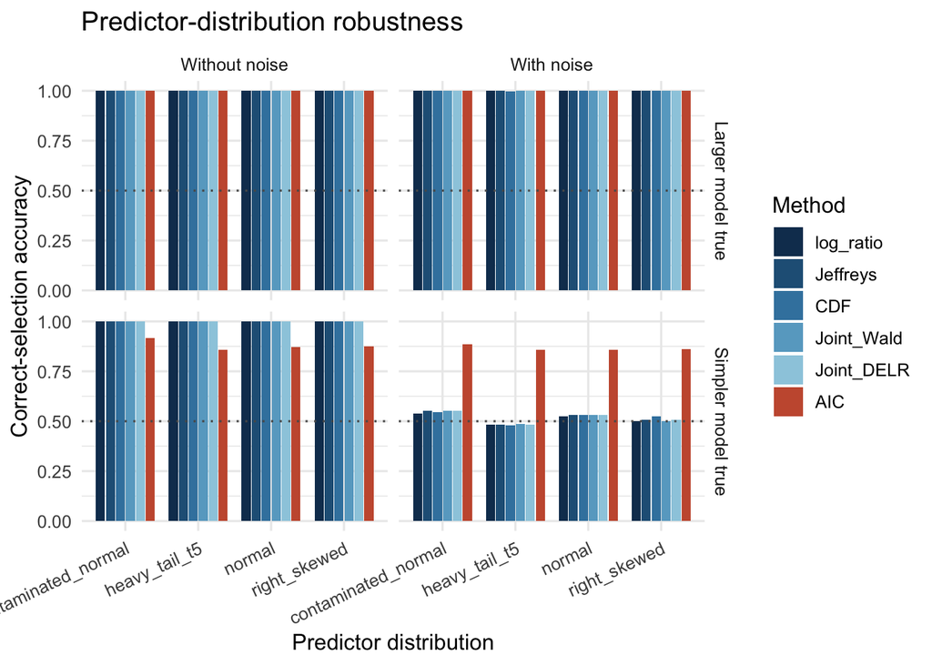

### Experiment 3: changing the error distribution

Every training-error distribution has mean zero and variance one. The fixed test response remains noiseless. Because an error distribution exists only in the with-noise training condition, this experiment reports only that condition.

**Accuracy under different error distributions**

With noise training: accuracy [95% Monte Carlo CI]

| true_model | error_distribution | log_ratio | Jeffreys | CDF | Joint_Wald | Joint_DELR | AIC |
| --- | --- | --- | --- | --- | --- | --- | --- |
| Simpler model true | normal | 0.562 [0.519, 0.605] | 0.562 [0.519, 0.605] | 0.558 [0.514, 0.602] | 0.558 [0.514, 0.602] | 0.560 [0.516, 0.604] | 0.860 [0.830, 0.890] |
| Larger model true | normal | 1.000 [1.000, 1.000] | 1.000 [1.000, 1.000] | 1.000 [1.000, 1.000] | 1.000 [1.000, 1.000] | 1.000 [1.000, 1.000] | 1.000 [1.000, 1.000] |
| Simpler model true | heavy_tail_t5 | 0.514 [0.470, 0.558] | 0.518 [0.474, 0.562] | 0.524 [0.480, 0.568] | 0.520 [0.476, 0.564] | 0.518 [0.474, 0.562] | 0.848 [0.817, 0.879] |
| Larger model true | heavy_tail_t5 | 1.000 [1.000, 1.000] | 1.000 [1.000, 1.000] | 1.000 [1.000, 1.000] | 1.000 [1.000, 1.000] | 1.000 [1.000, 1.000] | 1.000 [1.000, 1.000] |
| Simpler model true | right_skewed | 0.500 [0.456, 0.544] | 0.498 [0.454, 0.542] | 0.506 [0.462, 0.550] | 0.498 [0.454, 0.542] | 0.498 [0.454, 0.542] | 0.868 [0.838, 0.898] |
| Larger model true | right_skewed | 1.000 [1.000, 1.000] | 1.000 [1.000, 1.000] | 1.000 [1.000, 1.000] | 1.000 [1.000, 1.000] | 1.000 [1.000, 1.000] | 1.000 [1.000, 1.000] |
| Simpler model true | contaminated_normal | 0.546 [0.502, 0.590] | 0.552 [0.508, 0.596] | 0.530 [0.486, 0.574] | 0.554 [0.510, 0.598] | 0.552 [0.508, 0.596] | 0.852 [0.821, 0.883] |
| Larger model true | contaminated_normal | 1.000 [1.000, 1.000] | 1.000 [1.000, 1.000] | 1.000 [1.000, 1.000] | 1.000 [1.000, 1.000] | 1.000 [1.000, 1.000] | 1.000 [1.000, 1.000] |

**Delta under different error distributions**

With noise training: mean Delta [2.5%, 97.5% empirical quantiles]

| true_model | error_distribution | log_ratio | Jeffreys | CDF | Joint_Wald | Joint_DELR | AIC |
| --- | --- | --- | --- | --- | --- | --- | --- |
| Simpler model true | normal | 0.000 [-0.009, 0.008] | 0.000 [-0.007, 0.009] | 0.000 [-0.000, 0.000] | 0.041 [-0.615, 0.805] | 0.044 [-0.696, 0.852] | 1.900 [-4.047, 3.956] |
| Larger model true | normal | -6.379 [-20.454, -1.304] | -1.183 [-2.466, -0.483] | -0.009 [-0.013, -0.005] | -39.314 [-51.284, -27.125] | -78.608 [-130.657, -40.398] | -217.996 [-269.859, -170.268] |
| Simpler model true | heavy_tail_t5 | -0.000 [-0.010, 0.008] | 0.000 [-0.007, 0.010] | 0.000 [-0.000, 0.000] | 0.007 [-0.701, 0.942] | 0.007 [-0.728, 0.971] | 1.900 [-4.436, 3.960] |
| Larger model true | heavy_tail_t5 | -6.678 [-24.743, -1.313] | -1.211 [-2.714, -0.477] | -0.009 [-0.014, -0.004] | -39.545 [-52.759, -26.523] | -79.734 [-139.439, -39.173] | -216.468 [-272.455, -156.409] |
| Simpler model true | right_skewed | -0.001 [-0.012, 0.007] | 0.000 [-0.008, 0.008] | 0.000 [-0.000, 0.000] | 0.009 [-0.766, 0.707] | 0.006 [-0.822, 0.759] | 2.022 [-3.516, 3.956] |
| Larger model true | right_skewed | -6.663 [-20.687, -1.359] | -1.220 [-2.457, -0.490] | -0.009 [-0.014, -0.005] | -39.792 [-51.312, -27.241] | -80.398 [-131.237, -40.985] | -222.195 [-287.915, -163.980] |
| Simpler model true | contaminated_normal | -0.000 [-0.010, 0.008] | 0.000 [-0.008, 0.009] | 0.000 [-0.000, 0.000] | 0.027 [-0.766, 0.764] | 0.029 [-0.802, 0.850] | 1.951 [-2.947, 3.937] |
| Larger model true | contaminated_normal | -7.258 [-25.437, -1.198] | -1.268 [-2.758, -0.456] | -0.009 [-0.015, -0.004] | -40.111 [-53.457, -26.232] | -82.234 [-140.590, -38.416] | -220.196 [-308.393, -137.331] |

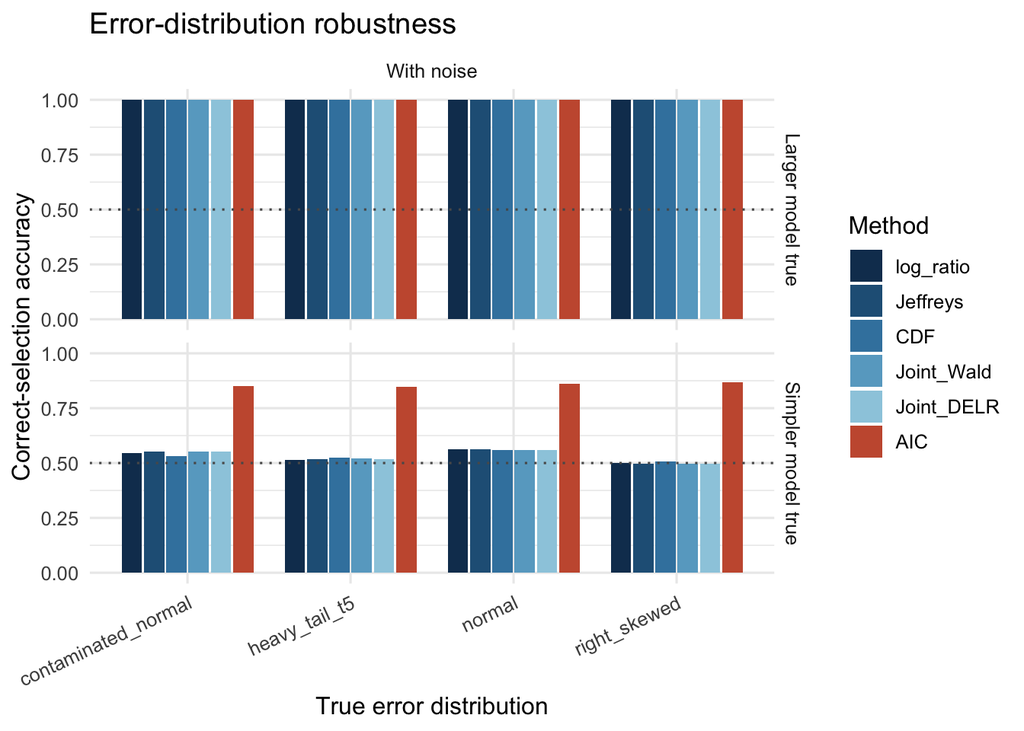

# Non-nested model

We compare two non-nested candidate models:

$$M_1:Y\sim X_1~~~~~~~vs
\qquad
M_2:Y\sim X_2+X_3.$$

$$X_1,X_2,X_3\overset{\mathrm{iid}}{\sim}N(0,1),
\qquad
\varepsilon\sim N(0,1).$$

$$M_1:~~~~Y=1+\beta_1X_1+\varepsilon,
\qquad
\mathrm{SNR}=\beta_1^2.$$

$$M_2:~~Y=1+\delta X_2+\delta X_3+\varepsilon,
\qquad
\mathrm{SNR}=2\delta^2.$$

These finite SNR values apply only to the with-noise training condition; the noiseless condition is not included in the SNR curve.

**Non-nested accuracy by SNR**

With noise training: accuracy [95% Monte Carlo CI]

| true_model | snr | log_ratio | Jeffreys | CDF | Joint_Wald | Joint_DELR | AIC |
| --- | --- | --- | --- | --- | --- | --- | --- |
| M1 true | 0.25 | 1.000 [1.000, 1.000] | 1.000 [1.000, 1.000] | 1.000 [1.000, 1.000] | 1.000 [1.000, 1.000] | 1.000 [1.000, 1.000] | 1.000 [1.000, 1.000] |
| M2 true | 0.25 | 1.000 [1.000, 1.000] | 1.000 [1.000, 1.000] | 1.000 [1.000, 1.000] | 1.000 [1.000, 1.000] | 1.000 [1.000, 1.000] | 1.000 [1.000, 1.000] |
| M1 true | 1.00 | 1.000 [1.000, 1.000] | 1.000 [1.000, 1.000] | 1.000 [1.000, 1.000] | 1.000 [1.000, 1.000] | 1.000 [1.000, 1.000] | 1.000 [1.000, 1.000] |
| M2 true | 1.00 | 1.000 [1.000, 1.000] | 1.000 [1.000, 1.000] | 1.000 [1.000, 1.000] | 1.000 [1.000, 1.000] | 1.000 [1.000, 1.000] | 1.000 [1.000, 1.000] |
| M1 true | 9.00 | 1.000 [1.000, 1.000] | 1.000 [1.000, 1.000] | 1.000 [1.000, 1.000] | 1.000 [1.000, 1.000] | 1.000 [1.000, 1.000] | 1.000 [1.000, 1.000] |
| M2 true | 9.00 | 1.000 [1.000, 1.000] | 1.000 [1.000, 1.000] | 1.000 [1.000, 1.000] | 1.000 [1.000, 1.000] | 1.000 [1.000, 1.000] | 1.000 [1.000, 1.000] |
| M1 true | 16.00 | 1.000 [1.000, 1.000] | 1.000 [1.000, 1.000] | 1.000 [1.000, 1.000] | 1.000 [1.000, 1.000] | 1.000 [1.000, 1.000] | 1.000 [1.000, 1.000] |
| M2 true | 16.00 | 1.000 [1.000, 1.000] | 1.000 [1.000, 1.000] | 1.000 [1.000, 1.000] | 1.000 [1.000, 1.000] | 1.000 [1.000, 1.000] | 1.000 [1.000, 1.000] |
| M1 true | 25.00 | 1.000 [1.000, 1.000] | 1.000 [1.000, 1.000] | 1.000 [1.000, 1.000] | 1.000 [1.000, 1.000] | 1.000 [1.000, 1.000] | 1.000 [1.000, 1.000] |
| M2 true | 25.00 | 1.000 [1.000, 1.000] | 1.000 [1.000, 1.000] | 1.000 [1.000, 1.000] | 1.000 [1.000, 1.000] | 1.000 [1.000, 1.000] | 1.000 [1.000, 1.000] |

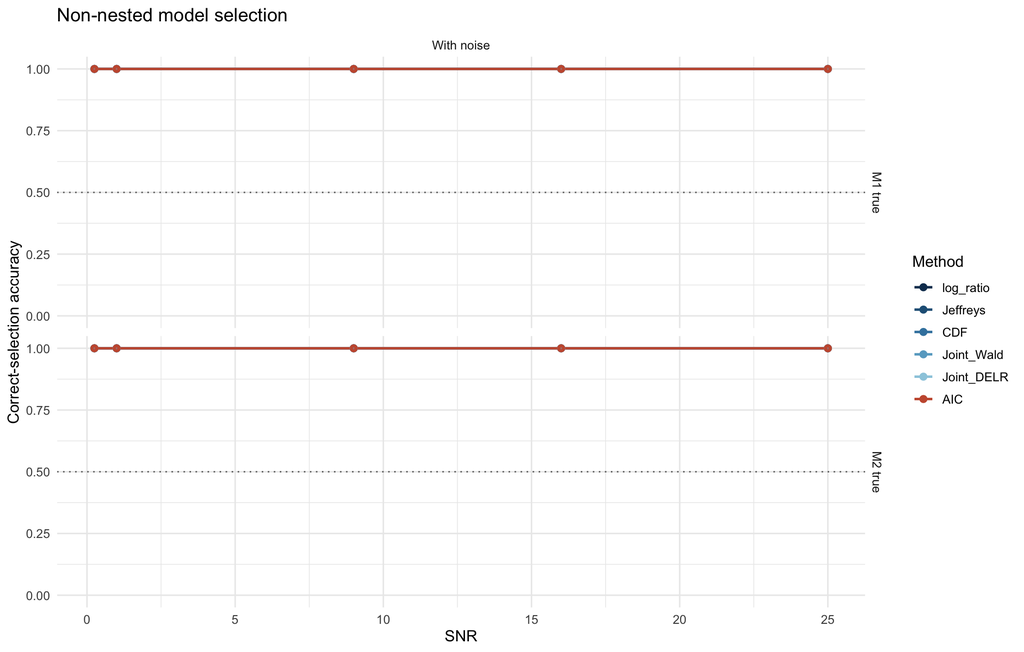